# CAT Bond Modeling - Back of the Envelope

# Caveats

- This is *extremely* back-of-the-envelope. Temperature, yield, and crops vary dramaticalyl across location in Indonesia, and location-specific modeling will be required for precises estimates
- Where probability distributions are used here, I deploy a Gaussian. In context, I think this is justifiable, but clearly debatable, particularly where extreme events are concerned and where nonstationarity is an issue.

# Steps

1. Using historical data since 1990, I simulate 10,000 (from here on, N) country-years of mean air temperature for Indonesia. Per the FAO, Indonesia has several different [growing seasons](http://www.fao.org/3/y4347e/y4347e0x.htm), encompassing 9 months of the year. I average across these growing season months in the historical data to get an annual “growing season mean temperature,” then fit the data to a normal distribution.
2. Using historical rice production data from the [FAO](http://www.fao.org/faostat/en/#data/QC/visualize), I project the growth in annual rice production forward to 2026 as a point estimate, then produce an estimate for annual production for the next five years by extracting N simulations from a Gaussian distribution around that point estimate (with the variance equal to that of the past five years).
3. I use an estimate from [recent research](https://www.nature.com/articles/nplants2016202#:~:text=More%20than%2080%25%20(67%20out,%25%20K%E2%88%921%20(Fig.) associating increased temperatures linearly with a percentage drop in rice yields, and calculate a loss curve using the temperature and yield distributions from (1) and (2). Production *increases* are reset to 0 and absolute value is taken so that the loss curve is expressed on the interval [0, infinity].
4. I use the current wholesale price for Indonesian rice to express the loss curve in terms of dollars, and plot an exceedance probability curve on this basis.
5. I estimate insurance premiums as the annualized payout risk over the term of a hypothetical policy for a given policy amount.

# Parameters

```r
# Parameters

######## Modeling ########
n <- 10000 # number of simulations
```

# Modules

## Exposure module

**Module purpose**: Define the hazard phenomena: for example, weather events that may impact the food supply. Simulate these events to get a distribution for their frequency and severity.

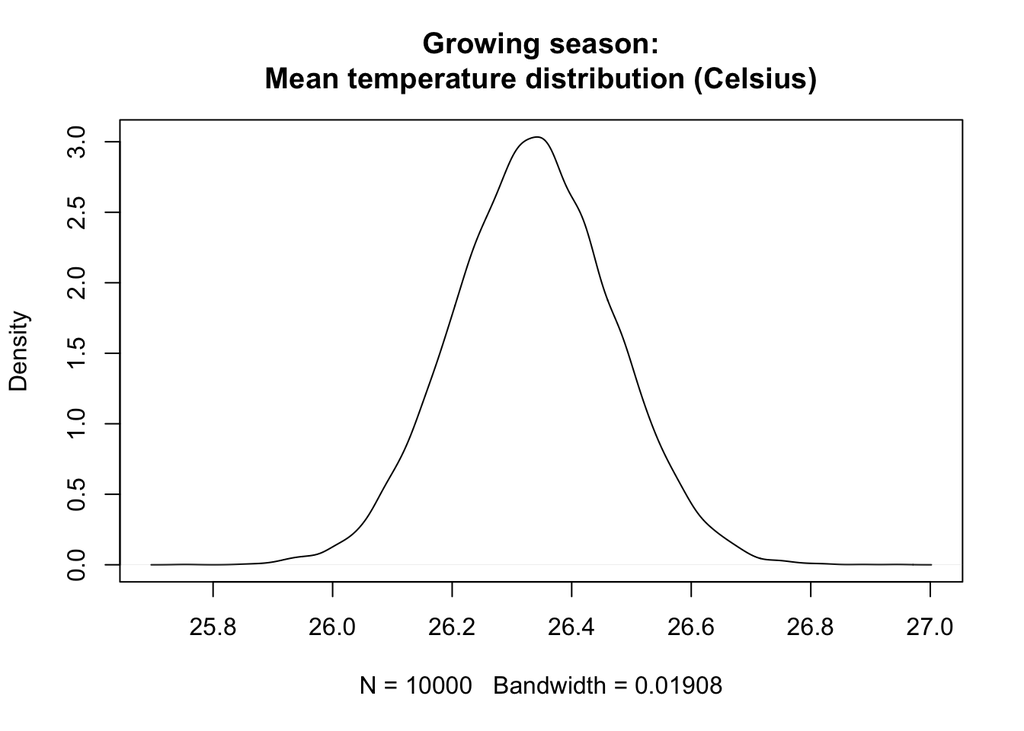

```r
# We want to come up with an annual distribution for mean growing season temperatures in Indonesia. For now, we use the last thirty years of data and assume a Gaussian distribution

earliest.year <- 1990

# It's planting season almost every month in various parts of Indonesia
growing.season.months <- c("MAR","APR","MAY","JUN","AUG","SEP","OCT","NOV","DEC")

history <- read.delim("data/temperature/ind.txt", sep="", skip=3) # historical monthly temperature data
history.small <- history %>% subset(YEAR >= earliest.year) %>% dplyr::select(growing.season.months)

#mean.temperatures <- unlist(history.small) # frame to vector of months
mean.temperatures <- rowMeans(history.small) # here averaging across growing season months to get a "mean growing season temperature"

# Fit a distribution to mean temperatures (very simple stan model)
data <- list(temp=mean.temperatures, N=length(mean.temperatures))
temperature.fit <- stan("temp_model.stan", data=data)
posterior <- extract(temperature.fit)

# Fetch parameters - median of the posterior distribution for each
mean_ <- median(posterior$mean_)
sigma_ <- median(posterior$sigma)

# Generate n samples according to model parameters (in this case normal)

### Temperature dist
temperatures <- rnorm(n, mean_, sigma_)

plot(density(temperatures), main="Growing season:\nMean temperature distribution (Celsius)")
```

## 2) Hazard module

**Module purpose**: Quantify the impact that the events described in the module (1) have on the food supply. Estimate a distribution of food supply shocks over all locations of interest.

Historical crop production data from [FAO](http://www.fao.org/faostat/en/#data/QC/visualize).

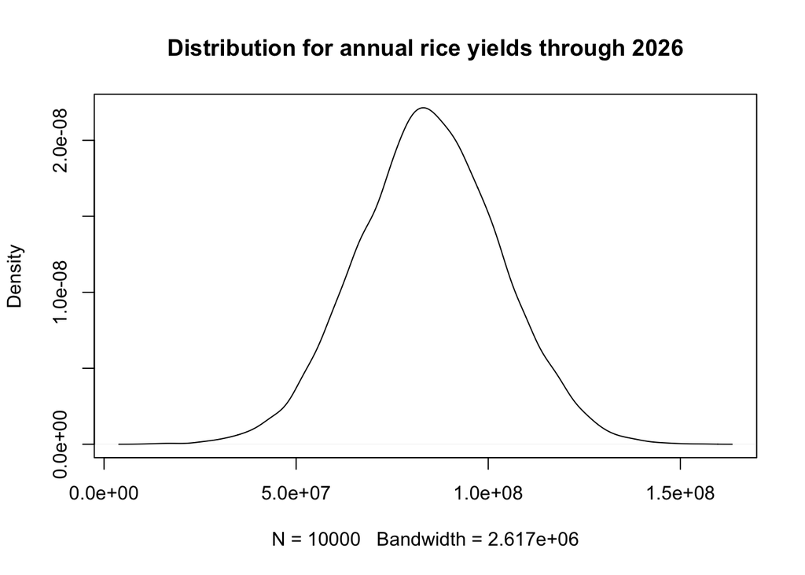

```r
# source: http://www.fao.org/faostat/en/#data/QC/visualize

fao.all <- read.csv("data/fao/Production_Crops_E_All_Data/Production_Crops_E_All_Data.csv")
fao.indonesia.rice <- fao.all %>% subset(Area == "Indonesia" & Item.Code == 27 & Element.Code == 5510) # historical rice production in Indonesia
indonesia.rice.reshaped <- data.frame(year=colnames(fao.indonesia.rice), value=c(t(fao.indonesia.rice)))
indonesia.rice.years <- indonesia.rice.reshaped %>% mutate(year = as.numeric(str_extract(year, "(?<=Y)[0-9][0-9][0-9][0-9]$")), value=as.numeric(value)) %>% subset(!is.na(year))

# shortcut to projecting the next five years: linear regression over the past thirty to get a trendline, then predict 2.5 years down the road and extract gaussian values around it
trend <- lm(value ~ year, data=indonesia.rice.years)
prediction_2.5 <- predict.lm(trend, data.frame(year=2026))

### Yield dist
yields <- rnorm(n, prediction_2.5, sd(indonesia.rice.years[-5:-1,'value'])) # using the variance over the past five years

plot(density(yields), main="Distribution for annual rice yields through 2026")
```

## 3) Vulnerability module

**Module purpose**: Combine exposure and hazard modules to estimate the potential damage at each location of interest (in this case the whole country).

Here we just assume an effect of temperature on yield based on estimates from [2]: -8.3% plus or minus 1.4% yield loss per degree Kelvin of warming (K = C + 273.15).

```r
loss.curve.yields <- function(temp.vector, yield.vector, increase) {
  yield.percentage.change <- (temp.vector - mean(temp.vector) + increase) * rnorm(n, -0.083, 0.007)
  yield.total.change <- yield.vector*yield.percentage.change

  # set non-losses to 0.
  lost.yields.only <- yield.total.change
  lost.yields.only[lost.yields.only > 0] <- 0
  lost.yields.only <- abs(lost.yields.only)
  return(lost.yields.only)
}

lost.yields.only <- loss.curve.yields(temperatures, yields, 0.07)
```

## 4) Financial module

**Module purpose**: Translate physical damage into monetary cost

As of right now, the [wholesale price](https://www.tridge.com/intelligences/rice/ID) of Indonesian rice is $0.78/kg, or $780 / ton. We convert crop production losses into dollar amounts using this figure.

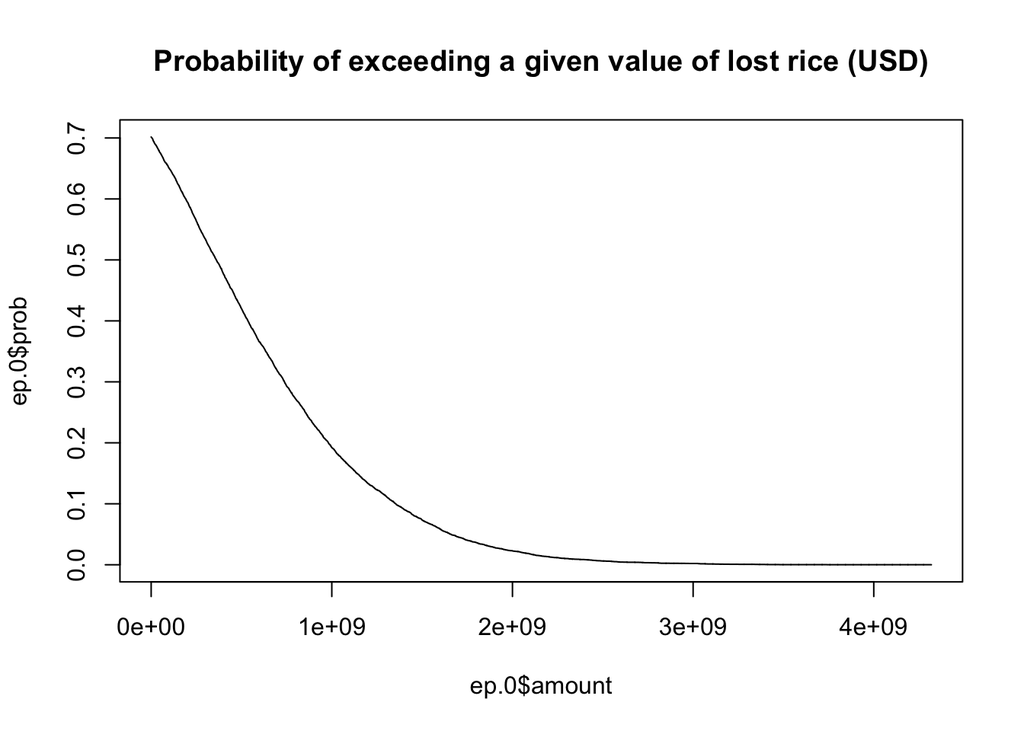

```r
loss.curve.dollars <- function(lost.yields, cost) {
  dollars.lost <- lost.yields * cost
  return(dollars.lost)
}

get.ep.curve <- function(loss.curve.input) {
  loss.amount <- seq(from = 0, to = max(loss.curve.input), length.out=n)
  ep <- sapply(loss.amount, function(x) { return(mean(loss.curve.input > x)) }, simplify="vector")
  return(data.frame(amount=loss.amount, prob=ep))
}

cost.per.ton.of.rice <- 780
loss.curve <- loss.curve.dollars(lost.yields.only, cost.per.ton.of.rice)

ep.0 <- get.ep.curve(loss.curve)

plot(ep.0$amount, ep.0$prob, type="l", main="Probability of exceeding a given value of lost rice (USD)") # plot EP curve
```

```r
# Get coefficient of variation for loss curve: CV = normalized variation
# Variability of loss curve = risk => affects premium
# can be calculated as the area under the EP curve or as the sum product of the mean loss and the annual likelihood of occurrence (ie, the event rate) for each event in the event set
# and can be used to evaluate the catastrophe load portion of an insurance rating function. AAL is often referred to as the pure premium or burn cost.
```

# Policy pricing

The United Nations Central Emergency Response Fund ([CERF](https://cerf.un.org/what-we-do/allocation/2020/sector/29/20-RR-SSD-40943/20-RR-WFP-015)) disburses food aid in the event of some severe food catastrophes. Recently, CERF disbursed $15m to feed 90,000 people over an 8-month period in South Sudan, suggesting a cost of ~$160 per person over the time period.

Basic ratemaking calculations for premium are sourced [here](https://www.casact.org/education/rpm/2012/handouts/Session_4764_presentation_965_0.pdf).

AIR [presentation](https://www.cia-ica.ca/docs/default-source/2018/218103e.pdf) on CAT bonds and pricing.

[How to calculate AAL](https://www.air-worldwide.com/publications/air-currents/2013/Modeling-Fundamentals--What-Is-AAL-/)

[Calculating risk load](https://www.casact.org/education/ratesem/2004/handouts/musulin.pdf)

```r
# set the maximum point on the EP curve to integrate up to
# this will reduce the sensitivity of the calculation to changes in the number of simulations
maximum.ep.curve.value <- 3400000000

bond.term = 5
rice.production.lost <- 0.05
base.rice.production <- 80000000

calculate.policy.amount <- function(rice.production.loss, rice.production) {
  policy.amount <- rice.production.loss*rice.production*cost.per.ton.of.rice
  return(policy.amount)
}

policy.amount <- calculate.policy.amount(rice.production.lost, base.rice.production)

#### Policy amount

# See source D.1
# average rate = (AAL + Risk Load + Fixed Expense)/(1 - Variable expense and profit ratio)
# Average risk load = (R * Sd) / (Exposure)
# Where sd is the standard deviation of the loss experience (calculated above)
# R is reluctance factor calculated according to "kreps" formula:
# R = (y * Z) / (1 + y)
# y = expected return => pick 10% as desired portfolio yield
# Z = "distribution percentage point corresponding to an acceptable probability that the actual result will require more surplus allocated" = 1.645 corresponds to 95%

# To investigate:
# variable permissible loss ratio?
# z-score below (!!!)
# exposure vs pure premium

calculate.average.rate <- function(ep.curve, policy.amount.input) {

  # Calculate the area under the curve to the right of the policy amount we target - this is the AAL. We use trapezoidal rule here to calculate AUC.
  ep <- ep.curve[ep.curve$amount >= policy.amount.input,]# & ep.curve$amount <= maximum.ep.curve.value,]
  id <- order(ep$amount)
  x <- ep$amount
  y = ep$prob
  AUC <- sum(diff(x[id])*rollmean(y[id],2))
  aal <- AUC
  sd.loss <- sd(ep$amount)

  exposure <- 1 # insured unit-years so- 1 country, Indonesia, in 1 year.
  pure.premium <- aal/exposure
  y <- 0.1      # desired portfolio yield
  z <- 1.645    # z-score for prob that actual result will require more surplus allocated
  R = (y * z)/(1 + y)  # reluctance factor
  risk.load <- (R * sd.loss)/exposure # replace with CV?

  # Components of variable expense and profit - values taken from example in source D.1
  commissions <- 0.2
  premium.tax <- 0.04
  underwriting.profit.provision <- 0.05
  trend.adjustment <- 0 # this is in the example but we leave it out for now
  fixed.expense = 25

  variable.expense.and.profit <- (commissions + premium.tax + underwriting.profit.provision) + trend.adjustment

  # This is the average rate, with assumed reinsurance = 0.
  # We still need to adjust this to get the per-unit premium
  average.rate <- (pure.premium + risk.load + fixed.expense) / (1 - variable.expense.and.profit)
  return(average.rate)
}

premium <- calculate.average.rate(ep.0, policy.amount)
premium
```

```
## [1] 73408388
```

```r
# print(paste("Expected premium assuming insured production loss of",loss,"and price per ton of",cost.per.ton.of.rice,":",premium$premium*100,"%"))
```

# Resilience rebate

Based on reference F.4, we make the following assumptions for Indonesia:

- Productivity of 1.10 kg/m/year
- Assumed upper-end production cost of $0.60/kg

We project an Indonesian aquaculture project that fully replaces the amount of rice lost in a temperature-induced disaster.

```r
calories.per.ton.of.rice <- 1000000 # back of the envelope

aquaculture.productivity <- 1.1 # kg per year - unused rn
aquaculture.cost <- 0.6 # per kg
aquaculture.cost.per.ton <- aquaculture.cost * 1000

# estimates based on F.5 - all estimates in this subsection are per 100 g
carbs.per.seaweed.gram <- 25
protein.per.seaweed.gram <- 15
fat.per.seaweed.gram <- 0.5
calories.per.carb.gram <- 4
calories.per.fat.gram <- 4
calories.per.protein.gram <- 9
calories.per.ton.of.seaweed <- ((carbs.per.seaweed.gram*calories.per.carb.gram) + (protein.per.seaweed.gram * calories.per.protein.gram) + (fat.per.seaweed.gram * calories.per.fat.gram)) * (1000000/100) # 1m grams per tonne, but estimates are per 100g

# calculate value of aquaculture project based on replacement cost
lost.rice.calories <- base.rice.production*rice.production.lost*calories.per.ton.of.rice
percentage.replaced <- 0.3
aquaculture.replacement.cost <- (lost.rice.calories / calories.per.ton.of.seaweed) * aquaculture.cost.per.ton * percentage.replaced
reduced.payout <- policy.amount*percentage.replaced

# aquaculture project cost
aquaculture.replacement.cost
```

```
## [1] 303797468
```

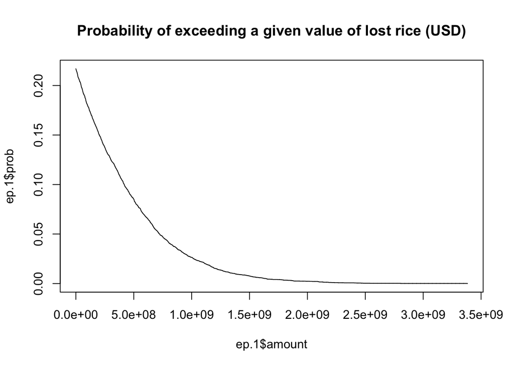

```r
# calculate rebate
loss.curve.1 <- loss.curve - reduced.payout
loss.curve.1[loss.curve.1 < 0] <- 0
ep.1 <- get.ep.curve(loss.curve.1)
plot(ep.1$amount, ep.1$prob, type="l", main="Probability of exceeding a given value of lost rice (USD)") # plot EP curve
```

```r
premium.1 <- calculate.average.rate(ep.1, policy.amount)
rebate <- (premium - premium.1)

# rebate value
rebate
```

```
## [1] 57378161
```

```r
# percentage of cost defrayed by rebate
rebate/aquaculture.replacement.cost
```

```
## [1] 0.1888698
```

# A. Data sources

A. [Climate research unit - monthly temperature data](https://crudata.uea.ac.uk/cru/data/hrg/cru_ts_4.03/crucy.1905151143.v4.03/new_countries/)

# B. End notes

1. [Assessing risks of climate variability and climate change for Indonesian rice agriculture](https://www.ncbi.nlm.nih.gov/pmc/articles/PMC1876519/)
2. [Plausible rice yield losses under future climate warming](https://www.nature.com/articles/nplants2016202#:~:text=More%20than%2080%25%20(67%20out,%25%20K%E2%88%921%20(Fig.)
3. [Food security, farming and climate change to 2050](https://www.ifpri.org/publication/food-security-farming-and-climate-change-2050)

# C. Modeling References

1. [Catastrophe Modeling: Guidance for Non-Catastrophe Modellers](https://www.lmalloyds.com/lma/finance/Cat_Modelling_Guidance.aspx)
2. [A Guide to Catastrophe Modeling](https://forms2.rms.com/rs/729-DJX-565/images/rms_guide_catastrophe_modeling_2008.pdf)
3. [Establishing flood damage functions for agricultural crops using estimated inundation depth and flood disaster statistics in data-scarce regions](https://www.jstage.jst.go.jp/article/hrl/11/1/11_12/_article)
4. [Evaluating CAT Bond Pricing Methods](https://pdfs.semanticscholar.org/c2d2/2651f9cc8504a998f8da4ef2a73c4a2d63ef.pdf)
5. [Modeling the Potential Impact of Catastrophic Weather on Crop Insurance Industry Portfolio Losses](https://www.researchgate.net/publication/23521744_Modeling_the_Potential_Impact_of_Catastrophic_Weather_on_Crop_Insurance_Industry_Portfolio_Losses)
6. [Income Elasticities and Global Values of a Statistical Life](https://law.vanderbilt.edu/phd/faculty/w-kip-viscusi/355_Income_Elasticities_and_Global_VSL.pdf) (unused here but included as a reference for later)
7. [Modeling Uncertainty in Climate Change: A Multi-Model Comparison](https://globalchange.mit.edu/sites/default/files/MITJPSPGC_Rpt290.pdf)
8. [An Evaluation of Decadal Probability Forecasts from State-of-the-Art Climate Models](https://journals.ametsoc.org/jcli/article/26/23/9334/99441/An-Evaluation-of-Decadal-Probability-Forecasts)
- Features “probability forecasts from ensembles” - using kernel dressing

# D. Insurance References

1. [AIR guide](https://www.cia-ica.ca/docs/default-source/2018/218103e.pdf) on CAT bonds and pricing.
2. [An example](https://www.chicagofed.org/publications/chicago-fed-letter/2018/405)
3. [An analysis of the market price of CAT bonds](https://www.casact.org/pubs/forum/09spforum/02Bodoff.pdf)
4. [Fundamentals of catastrophe modeling (presentation)](https://www.casact.org/education/rpm/2010/handouts/cmwa-hess.pdf)
5. [Overview of deductible ratemaking](https://www.soa.org/globalassets/assets/Files/Research/Projects/research-2016-gi-deductible-ratemaking.pdf)
6. [Worked example of CAT bond modeling](https://www.researchgate.net/publication/318990000_Uncertainty_Quantification_in_the_Design_of_Earthquake_Catastrophe_Bonds)

# E. Indonesia

- [Rice growing seasons in Indonesia](http://www.fao.org/3/y4347e/y4347e0x.htm)

# F. Aquaculture references

1. [FAO guide to Eucheuma Seaweed](http://www.fao.org/3/AC287E/AC287E03.htm)
2. [The Relative Caloric Prices of Healthy and Unhealthy Foods Differ Systematically across Income Levels and Continents](https://academic.oup.com/jn/article/149/11/2020/5535433)
3. [The Future of Food from the Sea](https://oceanpanel.org/sites/default/files/2019-11/19_HLP_BP1%20Paper.pdf)
4. [Seaweed Aquaculture for Food Security, Income Generation and Environmental Health in Tropical Developing Countries](http://documents1.worldbank.org/curated/en/947831469090666344/pdf/107147-WP-REVISED-Seaweed-Aquaculture-Web.pdf)
5. [A comparison of nutritional value of underexploited edible seaweeds with recommended dietary allowances](https://www.sciencedirect.com/science/article/pii/S1018364719318130)

# G. Helpful Miscellany

1. [Financing Catastrophe Risk for Famine Relief Using Early Warning Systems](http://globalagrisk.com/Pubs/2002%20Financing%20Catastrophe%20Risk%20for%20Famine%20Relief%20Using%20Early%20Warning%20jrs.pdf)
2. [2004 *Economist* article on potential WFP famine insurance](https://www.economist.com/finance-and-economics/2004/12/09/hedging-against-the-horsemen)
3. [Bond valuation on Investopedia](https://www.investopedia.com/terms/b/bond-valuation.asp)
4. [A useful blog post](https://understandinguncertainty.org/node/622)
5. [Overnight risk-free rates: A User’s Guide](https://www.fsb.org/wp-content/uploads/P040619-1.pdf)